# Лабораторная работа №3

Математический режим LaTeX

Оффеи Эндрю

Российский университет дружбы народов, Москва, Россия

2026

# Цель работы

# Основная цель

Изучение математического режима LaTeX, включая встроенные и отображаемые формулы, использование пакета `amsmath`, управление выравниванием и нумерацией уравнений, а также применение различных математических шрифтов.

# Exercise 3.8

# Компиляция исходного файла

Файл `exercise_3_8.tex` был открыт в текстовом редакторе и скомпилирован с помощью команды `pdflatex`.

Использовались: - TeX Live 2025  
- класс документа `article`  
- пакет `amsmath`

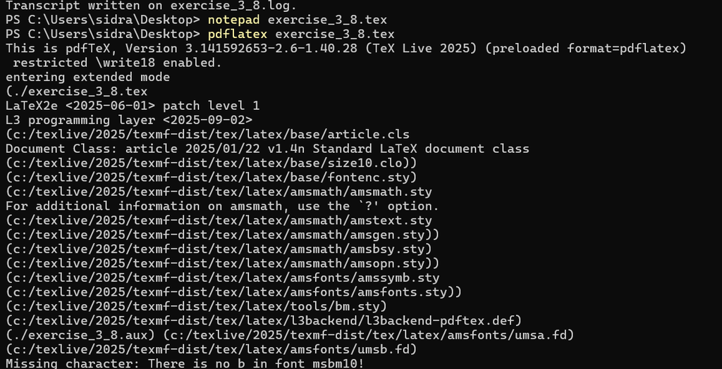

Компиляция exercise_3_8.tex

# Полученный результат

Сформированный PDF-документ содержит примеры:

- inline и display формул;
- интегралов;
- базовых математических конструкций.

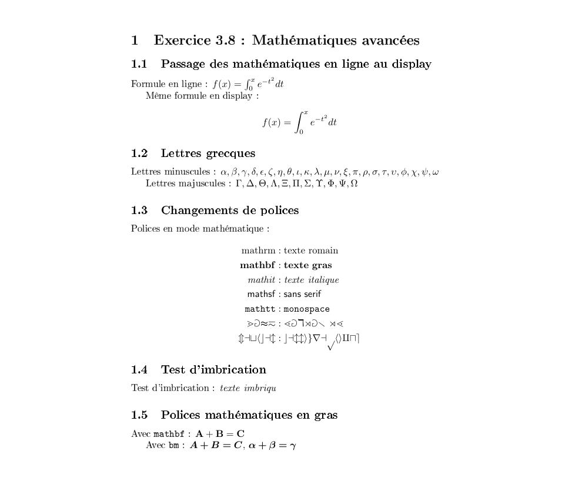

Результат Exercise 3.8

# Греческие буквы и шрифты

В документе продемонстрированы:

- строчные и заглавные греческие буквы;
- математические шрифты:
  - `\mathrm`
  - `\mathbf`
  - `\mathit`
  - `\mathsf`
  - `\mathtt`

# Жирная математика

Показано использование: - `\mathbf` — для латинских символов; - `\bm` — для греческих букв и знаков операций.

# Опции fleqn и leqno

# Компиляция с дополнительными опциями

Файл `exercise_3_8_options.tex` был скомпилирован с опциями:

- `fleqn` — выравнивание формул по левому краю;
- `leqno` — нумерация уравнений слева.

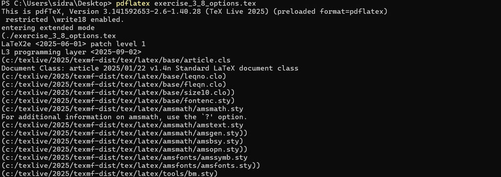

Компиляция exercise_3_8_options.tex

# Результат форматирования

В итоговом документе:

- формулы выровнены по левому краю;
- номера уравнений располагаются слева;
- корректно отображаются одиночные и многострочные уравнения.

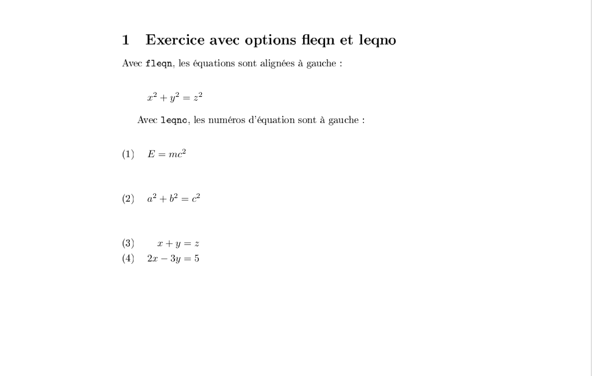

Результат fleqn и leqno

# Section 3.6 — amsmath

# Компиляция заданий

Скомпилированы файлы: - `exercise_3_6_simple.tex` - `exercise_3_7_simple.tex`

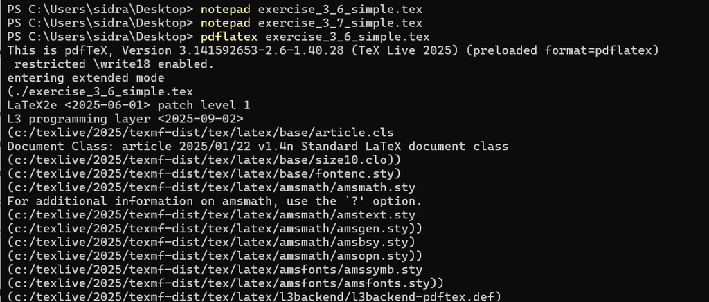

Компиляция Section 3.6 и 3.7

# Матрицы и выравнивание

В документе представлены:

- матрицы `pmatrix` и `bmatrix`;
- окружение `align` с нумерацией и без неё;
- многострочные формулы (`gather`).

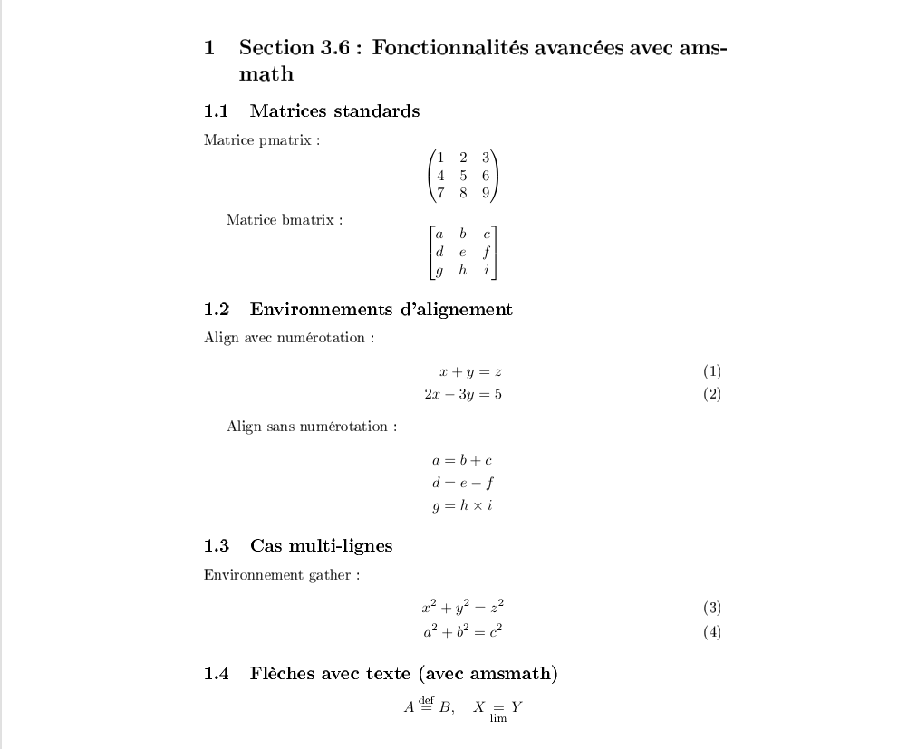

Результат Section 3.6

# Дополнительные возможности

Показано использование: - стрелок с текстом над и под ними; - логической структуры многострочных формул.

# Section 3.7 — Продвинутая математика

# Интегралы и суммы

Документ содержит примеры:

- определённых интегралов;
- сумм с пределами;
- математических выражений повышенной сложности.

# Логика и физика

Продемонстрированы: - логические квантификаторы; - сравнение математических шрифтов; - уравнения Максвелла с нумерацией.

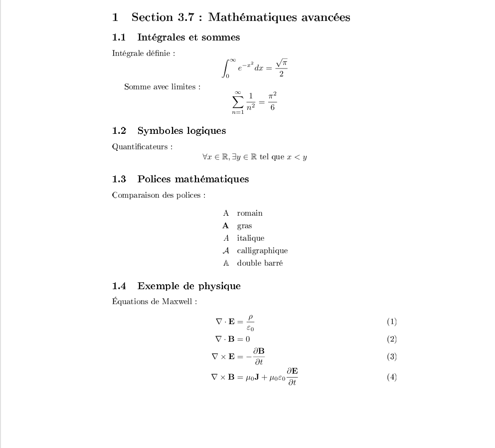

Результат Section 3.7

# Итоги работы

# Вывод

В ходе лабораторной работы были освоены:

- inline и display математический режим LaTeX;
- расширенные возможности пакета `amsmath`;
- работа с матрицами и многострочными формулами;
- управление шрифтами и жирным начертанием;
- влияние опций `fleqn` и `leqno`.

LaTeX предоставляет мощные средства для профессионального набора математических текстов.